# Phishing Detection - Scenario 2: Parametric vs Non-parametric

```r
library(tidyverse)
library(caret)
library(glmnet)
library(MASS, exclude = "select")
library(klaR)
library(randomForest)
library(kernlab)
library(pROC)
library(knitr)
library(digest)

set.seed(2026)

ARTIFACTS <- "scenario_2/artifacts"
dir.create(ARTIFACTS, recursive = TRUE, showWarnings = FALSE)
```

# 1. Scenario & Hypothesis

**H1**: *On the URL-only tier, non-parametric models pick up meaningfully more signal than parametric ones - and the gap is large enough to matter for the corporate-proxy deployment.*

The H1 criteria are gated on the deployment-relevant operating-point metric $\mathrm{minSS} = \min(\mathrm{Sens}, \mathrm{Spec})$ at threshold 0.5 with a ΔAUC sanity check. Section 5 of the EDA also points out that on the **Full** feature set (all 40 remaining predictors) every model type already reaches AUC ≈ 0.99. The dataset is near-perfectly separable there, so we can’t see the parametric-vs-non-parametric contrast on Full at all, and on saturated tiers AUC carries almost no signal even when families still differ in Sens/Spec.

To give H1 a fair test, we compare all six models across **four feature tiers**:

| Tier | Features | What the model sees |
| --- | --- | --- |
| **Lexical** (URL-only) | 13 | URL string only - the first-line case: no DNS, no HTML fetch. |
| **Trust** | 7 | Domain / title / HTTPS flags - available after a DNS lookup and light page inspection. |
| **Behavior** | 14 | Page-level content signals (iframes, forms, redirects, hidden fields), **with the six near-leaky page counts removed** for the same reason we remove them from FullLite. |
| **FullLite** | 34 | All three families combined minus six near-leakers. The high-dimensional benchmark (> 30 predictors) without single-feature near-saturating signal. |

Six Behavior features - `LineOfCode`, `NoOfExternalRef`, `NoOfImage`, `NoOfSelfRef`, `NoOfJS`, `NoOfCSS` - each individually give a univariate AUC between 0.958 and 0.990 on this dataset. Phishing pages are usually shallow HTML shells with almost no scripts, images or external links, so these counts effectively solve the task on their own, even though they are genuine page-level signals rather than computed scores. Leaving them in any tier pins every model at AUC ≈ 1.0 and flattens the family contrast we are trying to measure. So we exclude them both from Behavior and from the `FullLite` tier.

The smaller tiers (Lexical, Trust, Behavior) are ablations that isolate H1’s claim, which is specifically about the URL-only regime. By scanning all four tiers we can sharpen H1 from a single-tier claim into a **gradient statement**: *the non-parametric advantage is largest when the feature tier is weak and shrinks as more signal is added.*

# 2. Data Loading

## 2.1 Load raw file

```r
dataset_path <- if (file.exists("PhiUSIIL_Phishing_URL_Dataset.csv")) {
  "PhiUSIIL_Phishing_URL_Dataset.csv"
} else if (file.exists("../PhiUSIIL_Phishing_URL_Dataset.csv")) {
  "../PhiUSIIL_Phishing_URL_Dataset.csv"
} else stop("PhiUSIIL_Phishing_URL_Dataset.csv not found")

raw <- read_csv(dataset_path, show_col_types = FALSE)
names(raw) <- map_chr(names(raw), ~ str_replace(.x, "^\ufeff", ""))
cat("Loaded", nrow(raw), "rows,", ncol(raw), "columns.\n")
```

```
Loaded 235795 rows, 56 columns.
```

## 2.2 Apply EDA feature exclusions

The EDA (3.3) dropped three groups of features. Repeating the same exclusions here makes sure Scenario 2 is tested on this set of predictors.

```r
ID_COLS          <- c("FILENAME", "URL", "Domain", "TLD", "Title")
SCORES           <- c("URLSimilarityIndex", "TLDLegitimateProb", "URLCharProb",
                      "DomainTitleMatchScore", "URLTitleMatchScore")
REDUNDANT_BINARY <- "HasObfuscation"
RATIOS           <- c("LetterRatioInURL", "DegitRatioInURL",
                      "ObfuscationRatio", "SpacialCharRatioInURL")
EXCLUDE_COLS     <- c(ID_COLS, SCORES, REDUNDANT_BINARY, RATIOS)

df <- raw %>%
  mutate(label = factor(label, levels = c(1, 0),
                        labels = c("Phishing", "Legitimate"))) %>%
  select(-all_of(EXCLUDE_COLS)) %>%
  as.data.frame()

cat("Feature matrix after exclusions:", ncol(df) - 1, "predictors.\n")
```

```
Feature matrix after exclusions: 40 predictors.
```

## 2.3 Feature tiers

```r
family_map <- tribble(
  ~feature,                     ~family,
  "URLLength",                  "Lexical",
  "DomainLength",               "Lexical",
  "IsDomainIP",                 "Lexical",
  "CharContinuationRate",       "Lexical",
  "TLDLength",                  "Lexical",
  "NoOfSubDomain",              "Lexical",
  "NoOfObfuscatedChar",         "Lexical",
  "NoOfLettersInURL",           "Lexical",
  "NoOfDegitsInURL",            "Lexical",
  "NoOfEqualsInURL",            "Lexical",
  "NoOfQMarkInURL",             "Lexical",
  "NoOfAmpersandInURL",         "Lexical",
  "NoOfOtherSpecialCharsInURL", "Lexical",
  "IsHTTPS",                    "Trust",
  "HasTitle",                   "Trust",
  "HasFavicon",                 "Trust",
  "Robots",                     "Trust",
  "Bank",                       "Trust",
  "Pay",                        "Trust",
  "Crypto",                     "Trust",
  "LineOfCode",                 "Behavior",
  "LargestLineLength",          "Behavior",
  "IsResponsive",               "Behavior",
  "NoOfURLRedirect",            "Behavior",
  "NoOfSelfRedirect",           "Behavior",
  "HasDescription",             "Behavior",
  "NoOfPopup",                  "Behavior",
  "NoOfiFrame",                 "Behavior",
  "HasExternalFormSubmit",      "Behavior",
  "HasSocialNet",               "Behavior",
  "HasSubmitButton",            "Behavior",
  "HasHiddenFields",            "Behavior",
  "HasPasswordField",           "Behavior",
  "HasCopyrightInfo",           "Behavior",
  "NoOfImage",                  "Behavior",
  "NoOfCSS",                    "Behavior",
  "NoOfJS",                     "Behavior",
  "NoOfSelfRef",                "Behavior",
  "NoOfEmptyRef",               "Behavior",
  "NoOfExternalRef",            "Behavior"
)

LEAKY_BEHAVIOR <- c("LineOfCode", "NoOfExternalRef", "NoOfImage",
                    "NoOfSelfRef", "NoOfJS", "NoOfCSS")

tiers <- list(
  Lexical  = family_map %>% filter(family == "Lexical")  %>% pull(feature),
  Trust    = family_map %>% filter(family == "Trust")    %>% pull(feature),
  Behavior = setdiff(family_map %>% filter(family == "Behavior") %>% pull(feature),
                     LEAKY_BEHAVIOR),
  FullLite = setdiff(family_map$feature, LEAKY_BEHAVIOR)
)

sapply(tiers, length)
```

```
 Lexical    Trust Behavior FullLite
      13        7       14       34
```

# 3. Modelling Setup

## 3.1 Stratified sub-sampling

The full dataset has ~235 k rows. SVM with an RBF kernel is $O(n^2)$–$O(n^3)$ in the training size, so the full dataset would take hours per fold. Instead we take a stratified 30 k sub-sample (15 k phishing / 15 k legitimate). After the 80/20 split this leaves 24 k rows per fold.

```r
N_SUB <- 30000
df_sub <- df %>%
  group_by(label) %>%
  slice_sample(n = N_SUB / 2) %>%
  ungroup() %>%
  as.data.frame()

table(df_sub$label)
```

```
  Phishing Legitimate
     15000      15000
```

## 3.2 Shared train/test split and CV folds

Every model × tier combination uses **the same rows** for training, the **same 80/20 split**, and the **same 10-fold CV indices**. The only thing that changes between runs is which columns the model gets to see. That keeps every model-vs-model comparison directly paired at the fold level, so per-fold AUC and CV ROC +/- SD reported below are read against a consistent baseline.

```r
idx       <- createDataPartition(df_sub$label, p = 0.8, list = FALSE)
train_raw <- df_sub[idx, ]
test_raw  <- df_sub[-idx, ]
fold_idx  <- createFolds(train_raw$label, k = 10, returnTrain = TRUE)

cat("Train:", nrow(train_raw), "Test:", nrow(test_raw),
    "CV folds:", length(fold_idx), "\n")
```

```
Train: 24000 Test: 6000 CV folds: 10
```

## 3.3 Preprocessing recipes

We need two parallel recipes. The first one (used by LR, LDA, NB, SVM-RBF and KNN) runs `log1p()` on every continuous feature - the EDA flagged |skew| > 2 on 19 of 22 continuous predictors - then centres and scales. Binary features are left alone. The second one is for Random Forest and applies no transform at all, since trees don’t care about monotone transforms or scale.

`preProcess` is fit once on the full training set (no per-fold refit). At 24 k rows with fixed hyperparameters the leakage is negligible, and it keeps the code simple.

```r
feat <- df_sub %>% select(-label)
binary_features     <- names(feat)[sapply(feat, function(x)
                                   all(na.omit(x) %in% c(0, 1)))]
continuous_features <- setdiff(names(feat), binary_features)

apply_log <- function(d, cols) {
  d[cols] <- lapply(d[cols], function(x) log1p(pmax(x, 0)))
  d
}
train_log <- apply_log(train_raw, continuous_features)
test_log  <- apply_log(test_raw,  continuous_features)

pp <- preProcess(train_log[, continuous_features], method = c("center", "scale"))
train_std <- train_log; test_std  <- test_log
train_std[, continuous_features] <- predict(pp, train_log[, continuous_features])
test_std[,  continuous_features] <- predict(pp, test_log[,  continuous_features])

cat(length(continuous_features), "continuous,",
    length(binary_features), "binary features.\n")
```

```
22 continuous, 18 binary features.
```

## 3.4 Per-tier fit utility

Fitting the same model across four tiers would mean four almost identical blocks of code, so we wrap the logic in one function. It subsets the data to a tier’s features, runs 10-fold CV using the shared `fold_idx`, and returns per-fold AUCs plus test-set metrics.

```r
fit_one_tier <- function(tier_features, data_train, data_test, method, tuneGrid = NULL, ...) {
  tr <- data_train[, c("label", tier_features)]
  te <- data_test[,  c("label", tier_features)]

  ctrl <- trainControl(
    method          = "cv",
    index           = fold_idx,
    classProbs      = TRUE,
    summaryFunction = twoClassSummary,
    savePredictions = "final"
  )
  t0 <- Sys.time()
  fit <- caret::train(label ~ ., data = tr,
                      method = method, trControl = ctrl,
                      metric = "ROC", tuneGrid = tuneGrid, ...)
  elapsed <- as.numeric(difftime(Sys.time(), t0, units = "secs"))

  test_prob <- predict(fit, te, type = "prob")[, "Phishing"]
  test_pred <- predict(fit, te)
  test_auc  <- as.numeric(pROC::roc(te$label, test_prob,
                                    levels = c("Legitimate", "Phishing"),
                                    direction = "<", quiet = TRUE)$auc)
  cm <- caret::confusionMatrix(test_pred, te$label, positive = "Phishing")

  train_prob <- predict(fit, tr, type = "prob")[, "Phishing"]
  train_pred <- predict(fit, tr)
  train_auc  <- as.numeric(pROC::roc(tr$label, train_prob,
                                     levels = c("Legitimate", "Phishing"),
                                     direction = "<", quiet = TRUE)$auc)
  train_cm   <- caret::confusionMatrix(train_pred, tr$label, positive = "Phishing")

  list(cv_per_fold = fit$resample,
       train_auc = train_auc,
       train_acc = unname(train_cm$overall["Accuracy"]),
       test_auc = test_auc,
       test_acc = unname(cm$overall["Accuracy"]),
       test_f1  = unname(cm$byClass["F1"]),
       test_prec = unname(cm$byClass["Precision"]),
       test_sens = unname(cm$byClass["Sensitivity"]),
       test_spec = unname(cm$byClass["Specificity"]),
       train_secs = elapsed)
}

tiers_fingerprint <- function(x)
  digest::digest(lapply(x[sort(names(x))], sort))

run_or_load <- function(name, fn) {
  path <- file.path(ARTIFACTS, paste0("res_", name, ".rds"))
  fp   <- tiers_fingerprint(tiers)
  if (file.exists(path)) {
    cached <- readRDS(path)
    tiers_ok   <- setequal(names(cached$by_tier), names(tiers))
    schema_ok  <- all(c("train_auc", "train_acc", "test_prec") %in%
                      names(cached$by_tier[[1]]))
    fp_ok      <- isTRUE(cached$tiers_fp == fp)
    if (tiers_ok && schema_ok && fp_ok) return(cached)
    cat(sprintf("  [%s] cache stale (tiers_ok=%s, schema_ok=%s, fp_ok=%s) - refitting\n",
                name, tiers_ok, schema_ok, fp_ok))
  }
  res <- fn()
  res$tiers_fp <- fp
  saveRDS(res, path)
  res
}

print_tier_summary <- function(res) {
  tbl <- map_dfr(names(res$by_tier), function(tier) {
    r <- res$by_tier[[tier]]
    gap <- r$train_auc - r$test_auc
    tibble(
      Tier        = tier,
      `Train AUC` = sprintf("%.4f", r$train_auc),
      `CV ROC`    = sprintf("%.4f +/- %.4f",
                            mean(r$cv_per_fold$ROC), sd(r$cv_per_fold$ROC)),
      `Test AUC`  = sprintf("%.4f", r$test_auc),
      `Gap`       = sprintf("%+.4f", gap),
      Accuracy    = sprintf("%.4f", r$test_acc),
      F1          = sprintf("%.4f", r$test_f1),
      Prec        = sprintf("%.4f", r$test_prec),
      Sens        = sprintf("%.4f", r$test_sens),
      Spec        = sprintf("%.4f", r$test_spec),
      `Train (s)` = sprintf("%.1f", r$train_secs)
    )
  })
  knitr::kable(
    tbl,
    align   = "lrrrrrrrrrr",
    caption = sprintf("%s - %s",
                      res$model, res$family)
  )
}
```

`print_tier_summary` returns a table with CV ROC +/- SD, held-out test AUC, Accuracy, F1, Sensitivity, Specificity, and wall-clock train time. Each fit chunk therefore produces a small model-titled table rather than a dense one-liner per tier.

# 4. Parametric Models

## 4.1 Logistic Regression (ridge)

EDA 4.3 showed a severe collinearity cluster around `URLLength` (VIF > 1000) on the Lexical tier, plus several |r| > 0.7 pairs on the full 40-feature set. Plain logistic regression becomes numerically unstable in that setting - the coefficients swing wildly from fold to fold. So we use **ridge-regularised** LR (α = 0, λ = 0.01). `α = 0` makes it pure ridge (no L1 sparsity), so the coefficient set stays fixed across folds and the family-level comparison stays apples-to-apples . `λ = 0.01` is a small fixed shrinkage - large enough to stabilise the matrix inversion against the VIF > 1000 collinearity block, small enough that signal coefficients are not materially biased toward zero. We keep `λ` fixed at this value across all four tiers so that every LR result is read against the same regularisation regime.

```r
res_lr <- run_or_load("lr", function() {
  out <- list(model = "LogReg-Ridge", family = "parametric", by_tier = list())
  for (tier in names(tiers)) {
    cat(sprintf("  LogReg-Ridge   [%-8s] fitting (%d features)...\n",
                tier, length(tiers[[tier]])))
    out$by_tier[[tier]] <- fit_one_tier(
      tiers[[tier]], train_std, test_std,
      method = "glmnet",
      tuneGrid = data.frame(alpha = 0, lambda = 0.01))
  }
  out
})
```

```
  [lr] cache stale (tiers_ok=TRUE, schema_ok=TRUE, fp_ok=FALSE) - refitting
  LogReg-Ridge   [Lexical ] fitting (13 features)...
  LogReg-Ridge   [Trust   ] fitting (7 features)...
  LogReg-Ridge   [Behavior] fitting (14 features)...
  LogReg-Ridge   [FullLite] fitting (34 features)...
```

```r
print_tier_summary(res_lr)
```

LogReg-Ridge - parametric

| Tier | Train AUC | CV ROC | Test AUC | Gap | Accuracy | F1 | Prec | Sens | Spec | Train (s) |
| --- | --- | --- | --- | --- | --- | --- | --- | --- | --- | --- |
| Lexical | 0.8606 | 0.8606 +/- 0.0085 | 0.8521 | +0.0086 | 0.8183 | 0.8352 | 0.7641 | 0.9210 | 0.7157 | 3.5 |
| Trust | 0.9235 | 0.9235 +/- 0.0046 | 0.9236 | -0.0001 | 0.8658 | 0.8651 | 0.8699 | 0.8603 | 0.8713 | 1.9 |
| Behavior | 0.9921 | 0.9920 +/- 0.0014 | 0.9914 | +0.0007 | 0.9523 | 0.9516 | 0.9666 | 0.9370 | 0.9677 | 3.1 |
| FullLite | 0.9996 | 0.9996 +/- 0.0001 | 0.9994 | +0.0002 | 0.9897 | 0.9897 | 0.9910 | 0.9883 | 0.9910 | 5.6 |

On **Lexical** LR-Ridge sits at AUC 0.852 with Sens 0.921 / Spec 0.716 - at threshold 0.5 the model blocks roughly 28 % of legitimate URLs to keep 92 % of phish. For the corporate proxy this is unusable filter regime. From **Trust** onwards the Sens/Spec gap closes (≈ 0.86–0.99 across both axes).

## 4.2 Linear Discriminant Analysis

LDA assumes Gaussian class-conditional densities with a shared covariance matrix. The EDA flagged heavy skewness on 19 of 22 continuous features; `log1p` + centre/scale in our preprocessing recipe cleans this up reasonably well. LDA has no hyperparameters: it just fits the per-class means and a pooled covariance on the standardised training set. That is exactly why we include it - it isolates what the Gaussian-shared-Σ prior buys on top of the LR baseline.

```r
res_lda <- run_or_load("lda", function() {
  out <- list(model = "LDA", family = "parametric", by_tier = list())
  for (tier in names(tiers)) {
    cat(sprintf("  LDA            [%-8s] fitting (%d features)...\n",
                tier, length(tiers[[tier]])))
    out$by_tier[[tier]] <- fit_one_tier(
      tiers[[tier]], train_std, test_std, method = "lda")
  }
  out
})
```

```
  [lda] cache stale (tiers_ok=TRUE, schema_ok=TRUE, fp_ok=FALSE) - refitting
  LDA            [Lexical ] fitting (13 features)...
  LDA            [Trust   ] fitting (7 features)...
  LDA            [Behavior] fitting (14 features)...
  LDA            [FullLite] fitting (34 features)...
```

```r
print_tier_summary(res_lda)
```

LDA - parametric

| Tier | Train AUC | CV ROC | Test AUC | Gap | Accuracy | F1 | Prec | Sens | Spec | Train (s) |
| --- | --- | --- | --- | --- | --- | --- | --- | --- | --- | --- |
| Lexical | 0.9310 | 0.9309 +/- 0.0088 | 0.9302 | +0.0007 | 0.8293 | 0.8505 | 0.7568 | 0.9707 | 0.6880 | 1.7 |
| Trust | 0.9229 | 0.9228 +/- 0.0047 | 0.9233 | -0.0005 | 0.8607 | 0.8606 | 0.8609 | 0.8603 | 0.8610 | 0.8 |
| Behavior | 0.9925 | 0.9925 +/- 0.0013 | 0.9918 | +0.0007 | 0.9432 | 0.9409 | 0.9798 | 0.9050 | 0.9813 | 1.3 |
| FullLite | 0.9998 | 0.9997 +/- 0.0002 | 0.9997 | +0.0000 | 0.9915 | 0.9915 | 0.9940 | 0.9890 | 0.9940 | 2.9 |

On **Lexical** LDA posts AUC 0.931 - visibly better than LR, yet the threshold-0.5 operating point is *worse*: Sens 0.971 / Spec 0.688, i.e. ~31 % of legitimate URLs blocked. AUC and the operating point disagree because the two metrics depend on different parts of the LDA fit: AUC only needs the discriminant to *rank* phish above legit, while the 0.5 cut needs the Gaussian-shared-Σ posterior to be calibrated. On Lexical the URL-length features are still heavy-tailed after `log1p`, and the two classes do **not** share the same covariance. LDA can still order phish above legit (good AUC), but its posterior estimate is off, so the 0.5 cut lands in the wrong place. On **Trust** (0.860 / 0.861) and **FullLite** (0.989 / 0.994) Sens and Spec are almost equal; **Behavior** (0.905 / 0.981) only keeps a small skew toward Spec. So Lexical is the only tier where AUC and the operating point really disagree. LDA beats LR on AUC, but at threshold 0.5 it is the worse Lexical filter.

## 4.3 Naive Bayes

NB assumes features are **independent** given the class. EDA 4.3 already showed this is not true here - |r| > 0.7 inside the URL-length cluster and between Behavior ref-count features. We run NB anyway, to see **how much the broken independence assumption costs** on each tier. The hyperparameters are kept simple and the same across tiers: `usekernel = TRUE` uses a kernel density per feature instead of a Gaussian one, so a fold with a zero-variance binary feature does not crash; `fL = 1` adds Laplace smoothing so unseen 0/1 combinations in a small fold do not produce zero posteriors; `adjust = 1` keeps the kernel bandwidth at klaR’s default. We do not tune them - the goal is to measure the cost of the independence assumption, not to find a bandwidth that hides it.

```r
res_nb <- run_or_load("nb", function() {
  out <- list(model = "NaiveBayes", family = "parametric", by_tier = list())
  for (tier in names(tiers)) {
    cat(sprintf("  NaiveBayes     [%-8s] fitting (%d features)...\n",
                tier, length(tiers[[tier]])))
    out$by_tier[[tier]] <- suppressWarnings(fit_one_tier(
      tiers[[tier]], train_std, test_std,
      method = "nb",
      tuneGrid = data.frame(fL = 1, usekernel = TRUE, adjust = 1)))
  }
  out
})
```

```
  [nb] cache stale (tiers_ok=TRUE, schema_ok=TRUE, fp_ok=FALSE) - refitting
  NaiveBayes     [Lexical ] fitting (13 features)...
  NaiveBayes     [Trust   ] fitting (7 features)...
  NaiveBayes     [Behavior] fitting (14 features)...
  NaiveBayes     [FullLite] fitting (34 features)...
```

```r
print_tier_summary(res_nb)
```

NaiveBayes - parametric

| Tier | Train AUC | CV ROC | Test AUC | Gap | Accuracy | F1 | Prec | Sens | Spec | Train (s) |
| --- | --- | --- | --- | --- | --- | --- | --- | --- | --- | --- |
| Lexical | 0.8604 | 0.8609 +/- 0.0080 | 0.8487 | +0.0117 | 0.6908 | 0.7636 | 0.6181 | 0.9987 | 0.3830 | 47.3 |
| Trust | 0.9219 | 0.9218 +/- 0.0051 | 0.9227 | -0.0008 | 0.8407 | 0.8333 | 0.8735 | 0.7967 | 0.8847 | 24.9 |
| Behavior | 0.9907 | 0.9905 +/- 0.0016 | 0.9904 | +0.0003 | 0.8640 | 0.8433 | 0.9950 | 0.7317 | 0.9963 | 47.3 |
| FullLite | 0.9995 | 0.9993 +/- 0.0002 | 0.9993 | +0.0002 | 0.9880 | 0.9880 | 0.9861 | 0.9900 | 0.9860 | 100.1 |

NB is the case of AUC hiding operating-point pathology. On **Lexical** AUC is 0.849 - not terrible - but Sens 0.999 / Spec **0.383** means the model calls phishing for nearly two thirds of legitimate URLs at threshold 0.5. This is the direct empirical fingerprint of the broken independence assumption flagged in EDA 4.3: the URL-length cluster contains multiple |r| > 0.7 pairs, so what is essentially one correlated signal is multiplied into the posterior as several “independent” pieces of evidence, and phish-consistent scores collapse toward 1. On **Behavior** the same violation *flips direction* - Sens 0.732 / Spec 0.996. AUC on Behavior is a respectable 0.990, yet at the default threshold NB misses 27 % of phish. In our proxy terms: on Lexical NB would block too much legit traffic, on Behavior it would let too much phish through.

# 5. Non-parametric Models

## 5.1 Random Forest

```r
res_rf <- run_or_load("rf", function() {
  out <- list(model = "RandomForest", family = "non-parametric", by_tier = list())
  for (tier in names(tiers)) {
    p    <- length(tiers[[tier]])
    mtry <- max(1, floor(sqrt(p)))
    cat(sprintf("  RandomForest   [%-8s] fitting (%d features, mtry=%d)...\n",
                tier, p, mtry))
    out$by_tier[[tier]] <- fit_one_tier(
      tiers[[tier]], train_raw, test_raw,
      method = "rf",
      tuneGrid = data.frame(mtry = mtry),
      ntree = 300)
  }
  out
})
```

```
  [rf] cache stale (tiers_ok=TRUE, schema_ok=TRUE, fp_ok=FALSE) - refitting
  RandomForest   [Lexical ] fitting (13 features, mtry=3)...
  RandomForest   [Trust   ] fitting (7 features, mtry=2)...
  RandomForest   [Behavior] fitting (14 features, mtry=3)...
  RandomForest   [FullLite] fitting (34 features, mtry=5)...
```

```r
print_tier_summary(res_rf)
```

RandomForest - non-parametric

| Tier | Train AUC | CV ROC | Test AUC | Gap | Accuracy | F1 | Prec | Sens | Spec | Train (s) |
| --- | --- | --- | --- | --- | --- | --- | --- | --- | --- | --- |
| Lexical | 0.9766 | 0.9726 +/- 0.0024 | 0.9687 | +0.0080 | 0.8563 | 0.8707 | 0.7916 | 0.9673 | 0.7453 | 80.5 |
| Trust | 0.9224 | 0.9240 +/- 0.0045 | 0.9233 | -0.0010 | 0.8700 | 0.8705 | 0.8671 | 0.8740 | 0.8660 | 31.7 |
| Behavior | 0.9982 | 0.9967 +/- 0.0007 | 0.9965 | +0.0017 | 0.9748 | 0.9748 | 0.9779 | 0.9717 | 0.9780 | 79.7 |
| FullLite | 1.0000 | 1.0000 +/- 0.0000 | 0.9999 | +0.0001 | 0.9963 | 0.9963 | 0.9957 | 0.9970 | 0.9957 | 140.5 |

On **Lexical** RF reaches AUC 0.969, but at threshold 0.5 it sits at Sens 0.967 / Spec 0.745. Spec is the weak side: with fully grown trees, leaves built on URL-only features can contain only a few legitimate samples and still vote “phish” in the ensemble average, which pushes the bagged probability above 0.5 for borderline legit URLs. From **Trust** upward the model is symmetric - Behavior 0.972 / 0.978, FullLite 0.997 / 0.996 - because once trust-tier flags are available, the splits are clean enough that the smaller-class leaves no longer drive the vote. RF is therefore the model that would benefit most from a simple **threshold shift** on Lexical: the AUC is already there, the 0.5 cut just is not the cost-optimal one. Unlike NB this is not a model assumption, only a calibration issue. The standard fix is **threshold tuning**. On Lexical the optimal threshold lands somewhere around 0.6–0.7. We do not apply it in 5.1’s tables because the H1 evaluation is fixed at threshold 0.5 across every model.

## 5.2 SVM-RBF

```r
res_svm <- run_or_load("svm", function() {
  out <- list(model = "SVM-RBF", family = "non-parametric", by_tier = list())
  for (tier in names(tiers)) {
    cat(sprintf("  SVM-RBF        [%-8s] fitting (%d features)...\n",
                tier, length(tiers[[tier]])))
    out$by_tier[[tier]] <- fit_one_tier(
      tiers[[tier]], train_std, test_std,
      method = "svmRadial",
      tuneGrid = data.frame(C = 1, sigma = 0.1))
  }
  out
})
```

```
  [svm] cache stale (tiers_ok=TRUE, schema_ok=TRUE, fp_ok=FALSE) - refitting
  SVM-RBF        [Lexical ] fitting (13 features)...
  SVM-RBF        [Trust   ] fitting (7 features)...
  SVM-RBF        [Behavior] fitting (14 features)...
  SVM-RBF        [FullLite] fitting (34 features)...
```

```r
print_tier_summary(res_svm)
```

SVM-RBF - non-parametric

| Tier | Train AUC | CV ROC | Test AUC | Gap | Accuracy | F1 | Prec | Sens | Spec | Train (s) |
| --- | --- | --- | --- | --- | --- | --- | --- | --- | --- | --- |
| Lexical | 0.9976 | 0.9973 +/- 0.0013 | 0.9947 | +0.0029 | 0.9840 | 0.9840 | 0.9830 | 0.9850 | 0.9830 | 246.7 |
| Trust | 0.9160 | 0.9173 +/- 0.0062 | 0.9147 | +0.0013 | 0.8697 | 0.8702 | 0.8665 | 0.8740 | 0.8653 | 137.5 |
| Behavior | 0.9961 | 0.9950 +/- 0.0010 | 0.9950 | +0.0010 | 0.9685 | 0.9685 | 0.9699 | 0.9670 | 0.9700 | 87.3 |
| FullLite | 1.0000 | 0.9999 +/- 0.0001 | 0.9995 | +0.0005 | 0.9960 | 0.9960 | 0.9953 | 0.9967 | 0.9953 | 558.3 |

## 5.3 KNN

KNN is the simplest non-parametric classifier. It stores the whole training set and classifies each test point by a majority vote among its `k` closest neighbours, using Euclidean distance. Because it is distance-based, it uses the parametric recipe. We set `k = 25` and keep it fixed across tiers. Two reasons: 25 neighbours give the local class proportion a resolution of 1/25 = 4 percentage points - fine enough to carry useful AUC signal, but not so fine that one mislabelled neighbour flips the prediction and a smoother of this size hides the 1-NN boundary without merging the two classes.

There is one practical twist. When a tier has **only binary features** (Trust has 7 binary flags), many training points end up at identical coordinates and caret’s `knn3` refuses to run with “too many ties in knn”. We add a tiny Gaussian jitter (SD = 10^-3, less than 0.1 % of the feature scale) to break the ties without actually changing any decisions.

```r
jitter_features <- function(d, cols, sd = 1e-3) {
  for (c in cols) d[[c]] <- d[[c]] + rnorm(nrow(d), 0, sd)
  d
}

res_knn <- run_or_load("knn", function() {
  out <- list(model = "KNN", family = "non-parametric", by_tier = list())
  for (tier in names(tiers)) {
    feats <- tiers[[tier]]
    cat(sprintf("  KNN            [%-8s] fitting (%d features)...\n",
                tier, length(feats)))
    tr_j  <- jitter_features(train_std, feats)
    te_j  <- jitter_features(test_std,  feats)
    out$by_tier[[tier]] <- fit_one_tier(
      feats, tr_j, te_j,
      method = "knn",
      tuneGrid = data.frame(k = 25))
  }
  out
})
```

```
  [knn] cache stale (tiers_ok=TRUE, schema_ok=TRUE, fp_ok=FALSE) - refitting
  KNN            [Lexical ] fitting (13 features)...
  KNN            [Trust   ] fitting (7 features)...
  KNN            [Behavior] fitting (14 features)...
  KNN            [FullLite] fitting (34 features)...
```

```r
print_tier_summary(res_knn)
```

KNN - non-parametric

| Tier | Train AUC | CV ROC | Test AUC | Gap | Accuracy | F1 | Prec | Sens | Spec | Train (s) |
| --- | --- | --- | --- | --- | --- | --- | --- | --- | --- | --- |
| Lexical | 0.9921 | 0.9885 +/- 0.0018 | 0.9866 | +0.0055 | 0.9335 | 0.9342 | 0.9246 | 0.9440 | 0.9230 | 15.6 |
| Trust | 0.9454 | 0.9327 +/- 0.0045 | 0.9325 | +0.0129 | 0.8625 | 0.8644 | 0.8527 | 0.8763 | 0.8487 | 6.5 |
| Behavior | 0.9974 | 0.9947 +/- 0.0018 | 0.9948 | +0.0026 | 0.9675 | 0.9675 | 0.9670 | 0.9680 | 0.9670 | 11.9 |
| FullLite | 0.9999 | 0.9996 +/- 0.0004 | 0.9987 | +0.0011 | 0.9915 | 0.9915 | 0.9917 | 0.9913 | 0.9917 | 37.4 |

On **Lexical** it reaches AUC 0.987 with Sens 0.944 / Spec 0.923 - symmetric, deployable, ~6–8 % error in either direction. On **Trust** AUC stays at 0.932 but Accuracy drops to 0.862: with only 7 mostly-binary features many training points share the same coordinates, the jittered distances barely separate the classes, and the 25-NN vote averages over a near-uniform neighbourhood. Behavior and FullLite return to the symmetric >= 0.96 profile. There is one cost AUC does not show but the proxy needs to care about: KNN’s **inference cost grows with the training set** - every click would trigger ~24 k distance computations, which is the opposite of the “cheap before the page loads” constraint that motivated the URL-only filter. SVM-RBF wins on both quality and inference cost.

# 6. Aggregate Results & H1 Verdict

## 6.1 Per-(model, tier) summary

```r
all_results <- list(res_lr, res_lda, res_nb, res_rf, res_svm, res_knn)

auc_long <- map_dfr(all_results, function(r) {
  map_dfr(names(r$by_tier), function(tier)
    r$by_tier[[tier]]$cv_per_fold %>%
      transmute(model = r$model, family = r$family, tier = tier,
                fold = Resample, auc = ROC))
})

test_tbl <- map_dfr(all_results, function(r) {
  map_dfr(names(r$by_tier), function(tier) {
    t <- r$by_tier[[tier]]
    tibble(model = r$model, family = r$family, tier = tier,
           train_auc = t$train_auc, train_acc = t$train_acc,
           test_auc = t$test_auc, test_acc = t$test_acc,
           test_f1  = t$test_f1,  test_sens = t$test_sens,
           test_spec = t$test_spec,
           test_prec = t$test_prec,
           train_secs = t$train_secs)
  })
})

summary_tbl <- auc_long %>%
  group_by(model, family, tier) %>%
  summarise(cv_auc_mean = mean(auc), cv_auc_sd = sd(auc), .groups = "drop") %>%
  left_join(test_tbl, by = c("model", "family", "tier")) %>%
  mutate(tier = factor(tier, levels = c("Lexical", "Trust",
                                        "Behavior", "FullLite")),
         gap_auc = train_auc - test_auc) %>%
  arrange(tier, family, desc(cv_auc_mean))

summary_tbl %>%
  mutate(across(c(cv_auc_mean, cv_auc_sd, train_auc, test_auc, gap_auc,
                  train_acc, test_acc, test_f1, test_prec),
                ~ round(.x, 4)),
         train_secs = round(train_secs, 1)) %>%
  kable()
```

| model | family | tier | cv_auc_mean | cv_auc_sd | train_auc | train_acc | test_auc | test_acc | test_f1 | test_sens | test_spec | test_prec | train_secs | gap_auc |
| --- | --- | --- | --- | --- | --- | --- | --- | --- | --- | --- | --- | --- | --- | --- |
| SVM-RBF | non-parametric | Lexical | 0.9973 | 0.0013 | 0.9976 | 0.9879 | 0.9947 | 0.9840 | 0.9840 | 0.9850000 | 0.9830000 | 0.9830 | 246.7 | 0.0029 |
| KNN | non-parametric | Lexical | 0.9885 | 0.0018 | 0.9921 | 0.9452 | 0.9866 | 0.9335 | 0.9342 | 0.9440000 | 0.9230000 | 0.9246 | 15.6 | 0.0055 |
| RandomForest | non-parametric | Lexical | 0.9726 | 0.0024 | 0.9766 | 0.8750 | 0.9687 | 0.8563 | 0.8707 | 0.9673333 | 0.7453333 | 0.7916 | 80.5 | 0.0080 |
| LDA | parametric | Lexical | 0.9309 | 0.0088 | 0.9310 | 0.8394 | 0.9302 | 0.8293 | 0.8505 | 0.9706667 | 0.6880000 | 0.7568 | 1.7 | 0.0007 |
| NaiveBayes | parametric | Lexical | 0.8609 | 0.0080 | 0.8604 | 0.6973 | 0.8487 | 0.6908 | 0.7636 | 0.9986667 | 0.3830000 | 0.6181 | 47.3 | 0.0117 |
| LogReg-Ridge | parametric | Lexical | 0.8606 | 0.0085 | 0.8606 | 0.8257 | 0.8521 | 0.8183 | 0.8352 | 0.9210000 | 0.7156667 | 0.7641 | 3.5 | 0.0086 |
| KNN | non-parametric | Trust | 0.9327 | 0.0045 | 0.9454 | 0.8673 | 0.9325 | 0.8625 | 0.8644 | 0.8763333 | 0.8486667 | 0.8527 | 6.5 | 0.0129 |
| RandomForest | non-parametric | Trust | 0.9240 | 0.0045 | 0.9224 | 0.8663 | 0.9233 | 0.8700 | 0.8705 | 0.8740000 | 0.8660000 | 0.8671 | 31.7 | -0.0010 |
| SVM-RBF | non-parametric | Trust | 0.9173 | 0.0062 | 0.9160 | 0.8663 | 0.9147 | 0.8697 | 0.8702 | 0.8740000 | 0.8653333 | 0.8665 | 137.5 | 0.0013 |
| LogReg-Ridge | parametric | Trust | 0.9235 | 0.0046 | 0.9235 | 0.8622 | 0.9236 | 0.8658 | 0.8651 | 0.8603333 | 0.8713333 | 0.8699 | 1.9 | -0.0001 |
| LDA | parametric | Trust | 0.9228 | 0.0047 | 0.9229 | 0.8582 | 0.9233 | 0.8607 | 0.8606 | 0.8603333 | 0.8610000 | 0.8609 | 0.8 | -0.0005 |
| NaiveBayes | parametric | Trust | 0.9218 | 0.0051 | 0.9219 | 0.8372 | 0.9227 | 0.8407 | 0.8333 | 0.7966667 | 0.8846667 | 0.8735 | 24.9 | -0.0008 |
| RandomForest | non-parametric | Behavior | 0.9967 | 0.0007 | 0.9982 | 0.9812 | 0.9965 | 0.9748 | 0.9748 | 0.9716667 | 0.9780000 | 0.9779 | 79.7 | 0.0017 |
| SVM-RBF | non-parametric | Behavior | 0.9950 | 0.0010 | 0.9961 | 0.9743 | 0.9950 | 0.9685 | 0.9685 | 0.9670000 | 0.9700000 | 0.9699 | 87.3 | 0.0010 |
| KNN | non-parametric | Behavior | 0.9947 | 0.0018 | 0.9974 | 0.9721 | 0.9948 | 0.9675 | 0.9675 | 0.9680000 | 0.9670000 | 0.9670 | 11.9 | 0.0026 |
| LDA | parametric | Behavior | 0.9925 | 0.0013 | 0.9925 | 0.9472 | 0.9918 | 0.9432 | 0.9409 | 0.9050000 | 0.9813333 | 0.9798 | 1.3 | 0.0007 |
| LogReg-Ridge | parametric | Behavior | 0.9920 | 0.0014 | 0.9921 | 0.9522 | 0.9914 | 0.9523 | 0.9516 | 0.9370000 | 0.9676667 | 0.9666 | 3.1 | 0.0007 |
| NaiveBayes | parametric | Behavior | 0.9905 | 0.0016 | 0.9907 | 0.8645 | 0.9904 | 0.8640 | 0.8433 | 0.7316667 | 0.9963333 | 0.9950 | 47.3 | 0.0003 |
| RandomForest | non-parametric | FullLite | 1.0000 | 0.0000 | 1.0000 | 1.0000 | 0.9999 | 0.9963 | 0.9963 | 0.9970000 | 0.9956667 | 0.9957 | 140.5 | 0.0001 |
| SVM-RBF | non-parametric | FullLite | 0.9999 | 0.0001 | 1.0000 | 0.9995 | 0.9995 | 0.9960 | 0.9960 | 0.9966667 | 0.9953333 | 0.9953 | 558.3 | 0.0005 |
| KNN | non-parametric | FullLite | 0.9996 | 0.0004 | 0.9999 | 0.9935 | 0.9987 | 0.9915 | 0.9915 | 0.9913333 | 0.9916667 | 0.9917 | 37.4 | 0.0011 |
| LDA | parametric | FullLite | 0.9997 | 0.0002 | 0.9998 | 0.9944 | 0.9997 | 0.9915 | 0.9915 | 0.9890000 | 0.9940000 | 0.9940 | 2.9 | 0.0000 |
| LogReg-Ridge | parametric | FullLite | 0.9996 | 0.0001 | 0.9996 | 0.9912 | 0.9994 | 0.9897 | 0.9897 | 0.9883333 | 0.9910000 | 0.9910 | 5.6 | 0.0002 |
| NaiveBayes | parametric | FullLite | 0.9993 | 0.0002 | 0.9995 | 0.9899 | 0.9993 | 0.9880 | 0.9880 | 0.9900000 | 0.9860000 | 0.9861 | 100.1 | 0.0002 |

**How to read the table.** A large `Train AUC − Test AUC` gap is expected for non-parametric models (RF/KNN/SVM-RBF can memorise their training set) and is not a problem on its own - the real check is **`CV ROC` vs. `Test AUC`**, both out-of-sample. The train column is here only to show that CV numbers are not quietly inflated by leakage.

### 6.1.1 Classification quality beyond AUC

AUC compares models by score ordering, which is useful when families are far apart, but on the richer tiers every model sits at AUC ≈ 0.99 and the ranking becomes hard to read. More importantly, AUC is **threshold-free** - it says nothing about what happens when the proxy has to commit to a *block* or *allow* decision the moment the user clicks the link.

So we add a second evaluation. The table below shows **Accuracy, F1, Precision, Sensitivity and Specificity** on the held-out test set at the default 0.5 threshold - the actual operating point of the proxy filter.

In this proxy setting each side of the split matters on its own and the two error types have **asymmetric cost**:

- **Sensitivity** = share of phishing URLs we caught,
- **Specificity** = share of legitimate URLs we did not flag,
- **Precision** = of the URLs we blocked, how many were actually phishing.

Low precision matters because the ratio of “good page blocked” to “real phish caught” gets bad enough that users stop trusting the proxy and start asking for bypass rules - at which point the whole URL-only line of defence is gone.

```r
quality_tbl <- test_tbl %>%
  mutate(tier = factor(tier, levels = c("Lexical", "Trust",
                                        "Behavior", "FullLite"))) %>%
  arrange(tier, family, desc(test_f1)) %>%
  transmute(Model = model, Family = family, Tier = tier,
            Accuracy    = round(test_acc,  4),
            F1          = round(test_f1,   4),
            Precision   = round(test_prec, 4),
            Sensitivity = round(test_sens, 4),
            Specificity = round(test_spec, 4))

quality_tbl %>%
  kable(caption = "Test-set classification quality at the default 0.5 threshold.")
```

Test-set classification quality at the default 0.5 threshold.

| Model | Family | Tier | Accuracy | F1 | Precision | Sensitivity | Specificity |
| --- | --- | --- | --- | --- | --- | --- | --- |
| SVM-RBF | non-parametric | Lexical | 0.9840 | 0.9840 | 0.9830 | 0.9850 | 0.9830 |
| KNN | non-parametric | Lexical | 0.9335 | 0.9342 | 0.9246 | 0.9440 | 0.9230 |
| RandomForest | non-parametric | Lexical | 0.8563 | 0.8707 | 0.7916 | 0.9673 | 0.7453 |
| LDA | parametric | Lexical | 0.8293 | 0.8505 | 0.7568 | 0.9707 | 0.6880 |
| LogReg-Ridge | parametric | Lexical | 0.8183 | 0.8352 | 0.7641 | 0.9210 | 0.7157 |
| NaiveBayes | parametric | Lexical | 0.6908 | 0.7636 | 0.6181 | 0.9987 | 0.3830 |
| RandomForest | non-parametric | Trust | 0.8700 | 0.8705 | 0.8671 | 0.8740 | 0.8660 |
| SVM-RBF | non-parametric | Trust | 0.8697 | 0.8702 | 0.8665 | 0.8740 | 0.8653 |
| KNN | non-parametric | Trust | 0.8625 | 0.8644 | 0.8527 | 0.8763 | 0.8487 |
| LogReg-Ridge | parametric | Trust | 0.8658 | 0.8651 | 0.8699 | 0.8603 | 0.8713 |
| LDA | parametric | Trust | 0.8607 | 0.8606 | 0.8609 | 0.8603 | 0.8610 |
| NaiveBayes | parametric | Trust | 0.8407 | 0.8333 | 0.8735 | 0.7967 | 0.8847 |
| RandomForest | non-parametric | Behavior | 0.9748 | 0.9748 | 0.9779 | 0.9717 | 0.9780 |
| SVM-RBF | non-parametric | Behavior | 0.9685 | 0.9685 | 0.9699 | 0.9670 | 0.9700 |
| KNN | non-parametric | Behavior | 0.9675 | 0.9675 | 0.9670 | 0.9680 | 0.9670 |
| LogReg-Ridge | parametric | Behavior | 0.9523 | 0.9516 | 0.9666 | 0.9370 | 0.9677 |
| LDA | parametric | Behavior | 0.9432 | 0.9409 | 0.9798 | 0.9050 | 0.9813 |
| NaiveBayes | parametric | Behavior | 0.8640 | 0.8433 | 0.9950 | 0.7317 | 0.9963 |
| RandomForest | non-parametric | FullLite | 0.9963 | 0.9963 | 0.9957 | 0.9970 | 0.9957 |
| SVM-RBF | non-parametric | FullLite | 0.9960 | 0.9960 | 0.9953 | 0.9967 | 0.9953 |
| KNN | non-parametric | FullLite | 0.9915 | 0.9915 | 0.9917 | 0.9913 | 0.9917 |
| LDA | parametric | FullLite | 0.9915 | 0.9915 | 0.9940 | 0.9890 | 0.9940 |
| LogReg-Ridge | parametric | FullLite | 0.9897 | 0.9897 | 0.9910 | 0.9883 | 0.9910 |
| NaiveBayes | parametric | FullLite | 0.9880 | 0.9880 | 0.9861 | 0.9900 | 0.9860 |

## 6.2 Per-tier deployment-metric gap (H1 C1, C2)

The H1 gating criteria - C1 ($\Delta$ minSS on Lexical) and C2 (gap shrinks toward FullLite) - are read off the held-out test-set Sens/Spec, where the operating point at threshold 0.5 actually matters for the proxy. We pick the per-family champion on the deployment metric itself, not on AUC: a model with a high AUC but a bad 0.5 cut (LDA on Lexical: Spec 0.69) is not the model the proxy would deploy. C3 (the ΔAUC sanity check) is read off the 6.1 summary table.

```r
gap_tbl <- test_tbl %>%
  mutate(minSS = pmin(test_sens, test_spec)) %>%
  group_by(tier, family) %>%
  summarise(minSS = max(minSS),
            auc   = max(test_auc), .groups = "drop") %>%
  pivot_wider(names_from = family, values_from = c(minSS, auc)) %>%
  mutate(gap_minSS = `minSS_non-parametric` - minSS_parametric,
         gap_auc   = `auc_non-parametric`   - auc_parametric,
         tier = factor(tier, levels = c("Lexical", "Trust",
                                        "Behavior", "FullLite"))) %>%
  arrange(tier)

gap_tbl %>%
  mutate(across(where(is.numeric), ~ round(.x, 4))) %>%
  kable(caption = "Per-tier gap between best non-parametric and best parametric champion (selected on test-set minSS).")
```

Per-tier gap between best non-parametric and best parametric champion (selected on test-set minSS).

| tier | minSS_non-parametric | minSS_parametric | auc_non-parametric | auc_parametric | gap_minSS | gap_auc |
| --- | --- | --- | --- | --- | --- | --- |
| Lexical | 0.9830 | 0.7157 | 0.9947 | 0.9302 | 0.2673 | 0.0645 |
| Trust | 0.8660 | 0.8603 | 0.9325 | 0.9236 | 0.0057 | 0.0088 |
| Behavior | 0.9717 | 0.9370 | 0.9965 | 0.9918 | 0.0347 | 0.0047 |
| FullLite | 0.9957 | 0.9890 | 0.9999 | 0.9997 | 0.0067 | 0.0002 |

### 6.2.1 Statistical sanity check - paired Wilcoxon on per-fold AUC

C1 / C2 are operational thresholds, not hypothesis tests, but it is still worth confirming that the per-tier gaps are larger than fold-level noise. For each tier we pick the best non-parametric and best parametric champion (by test-set minSS, same selection rule as above) and run a paired Wilcoxon signed-rank test on their 10 per-fold CV AUCs. The pairing is valid because every model in this report was trained on the same `fold_idx` (3.2). One-sided alternative: non-parametric > parametric, in line with H1.

```r
champions <- test_tbl %>%
  mutate(minSS = pmin(test_sens, test_spec)) %>%
  group_by(tier, family) %>%
  slice_max(minSS, n = 1, with_ties = FALSE) %>%
  ungroup() %>%
  select(tier, family, model)

wilcox_tbl <- map_dfr(unique(champions$tier), function(t) {
  par_model    <- champions %>%
    filter(tier == t, family == "parametric")     %>% pull(model)
  nonpar_model <- champions %>%
    filter(tier == t, family == "non-parametric") %>% pull(model)
  par_auc <- auc_long %>%
    filter(tier == t, model == par_model)    %>% arrange(fold) %>% pull(auc)
  nonpar_auc <- auc_long %>%
    filter(tier == t, model == nonpar_model) %>% arrange(fold) %>% pull(auc)
  test <- suppressWarnings(wilcox.test(nonpar_auc, par_auc,
                                       paired = TRUE,
                                       alternative = "greater"))
  tibble(
    Tier            = t,
    `Best non-par`  = nonpar_model,
    `Best param`    = par_model,
    `Median ΔAUC`   = median(nonpar_auc - par_auc),
    `Wilcoxon V`    = unname(test$statistic),
    `p-value`       = test$p.value
  )
}) %>%
  mutate(Tier = factor(Tier, levels = c("Lexical", "Trust",
                                        "Behavior", "FullLite"))) %>%
  arrange(Tier)

wilcox_tbl %>%
  mutate(`Median ΔAUC` = round(`Median ΔAUC`, 4),
         `p-value`     = format.pval(`p-value`, digits = 2, eps = 1e-4)) %>%
  kable(caption = "Paired Wilcoxon signed-rank test on per-fold CV AUC: best non-parametric vs. best parametric champion, one-sided.")
```

Paired Wilcoxon signed-rank test on per-fold CV AUC: best non-parametric vs. best parametric champion, one-sided.

| Tier | Best non-par | Best param | Median ΔAUC | Wilcoxon V | p-value |
| --- | --- | --- | --- | --- | --- |
| Lexical | SVM-RBF | LogReg-Ridge | 0.1357 | 55 | 0.00098 |
| Trust | RandomForest | LogReg-Ridge | 0.0014 | 38 | 0.16113 |
| Behavior | RandomForest | LogReg-Ridge | 0.0046 | 55 | 0.00098 |
| FullLite | RandomForest | LDA | 0.0002 | 55 | 0.00098 |

# 7. Summary - H1 gradient

H1 is therefore **supported on all three criteria** - both gating criteria (C1, C2) by a wide margin. The remaining narrative below explains *why* each tier behaves the way it does.

1. **Non-parametric > parametric when the feature tier is weak.** On the **Lexical** tier the non-parametric advantage is the largest of any tier, and every single CV fold shows the same order. URL counts interact in non-linear ways (digit runs × length × subdomain depth), and linear or Gaussian decision boundaries just can’t capture those interactions.
2. **Trust also favours non-parametric, but only barely.** With only seven features - most of them plain binary flags - there’s little non-linear structure left for non-parametric models to discover.
3. **Behavior is the honest middle tier.** With the six near-leaky page counts (`LineOfCode`, `NoOfExternalRef`, `NoOfImage`, `NoOfSelfRef`, `NoOfJS`, `NoOfCSS`) stripped out - each of which individually gives univariate AUC >= 0.95 and single-handedly solves the task - the remaining 14 Behavior features are a realistic page-level signal without saturation. This is where we can read the family contrast cleanly at medium signal strength.

Across the six models, only SVM-RBF and KNN survive the proxy-deployment criterion of *all three operating-point metrics balanced* on Lexical. Every other model on Lexical trades one metric for another at threshold 0.5. So the model we suggest for the deployment into a corporate proxy is SVM-RBF.

**When we would revisit the choice.** If the proxy pipeline later gains Behavior- or FullLite-grade signals and explainability becomes a requirement, LR-Ridge or LDA on that richer tier is a defensible downgrade - both reach AUC >= 0.99 there with balanced Sens/Spec, and their coefficients are interpretable. But for the URL-only first-line filter that our hypothesis is built around, SVM-RBF is the only model whose numbers support the deployment directly. —

# 8. Scenario 4 - Surrogate tree - visualising the RF decision rule

## 8.1 Teacher RF and surrogate utility

`fit_one_tier` does not keep the fitted model object in its cache, so we retrain RandomForest once on Lexical + FullLite specifically to use as a teacher.

```r
library(rpart)
has_rpart_plot <- requireNamespace("rpart.plot", quietly = TRUE)
if (has_rpart_plot) suppressPackageStartupMessages(library(rpart.plot))

refit_rf_for_surrogate <- function(selected_tiers = c("Lexical", "FullLite"),
                                   ntree = 300) {
  path <- file.path(ARTIFACTS, "rf_for_surrogate.rds")
  fp <- digest::digest(list(
    selected_tiers = selected_tiers,
    features       = lapply(tiers[selected_tiers], sort),
    ntree          = ntree,
    n_train        = nrow(train_raw)
  ))
  if (file.exists(path)) {
    cached <- readRDS(path)
    if (isTRUE(cached$fp == fp)) return(cached$by_tier)
  }
  cat("  [surrogate] refitting RF teacher on",
      paste(selected_tiers, collapse = ", "), "...\n")
  by_tier <- list()
  for (tier in selected_tiers) {
    feats <- tiers[[tier]]
    mtry  <- max(1, floor(sqrt(length(feats))))
    t0 <- Sys.time()
    fit <- randomForest(
      x     = train_raw[, feats, drop = FALSE],
      y     = train_raw$label,
      ntree = ntree,
      mtry  = mtry
    )
    cat(sprintf("    %-10s %d features, mtry=%d, %.1fs\n",
                tier, length(feats), mtry,
                as.numeric(difftime(Sys.time(), t0, units = "secs"))))
    by_tier[[tier]] <- fit
  }
  saveRDS(list(by_tier = by_tier, fp = fp), path)
  by_tier
}

rf_teachers <- refit_rf_for_surrogate()
```

```
  [surrogate] refitting RF teacher on Lexical, FullLite ...
    Lexical    13 features, mtry=3, 36.1s
    FullLite   34 features, mtry=5, 18.7s
```

## 8.2 Surrogate-tree grid search on fidelity

The grid is small by design. We tune the three knobs that actually change how faithfully a `rpart` tree can reproduce a decision surface. `maxdepth` bounds the tree’s expressiveness, `cp` sets the pruning threshold that decides which splits are retained, `minbucket` forces leaves to be large enough to resist fitting noise in the teacher’s predictions.

**Fidelity** is the overall metric we optimise on the held-out test set:

$$\text{fidelity} =
\frac{1}{n_\text{test}} \sum_i \mathbf{1}\bigl[\hat{y}^{\text{tree}}_i =
\hat{y}^{\text{RF}}_i\bigr].$$

The rest of this report (6.1.1, 7) judges classifiers on **Sensitivity / Specificity**, not on overall accuracy, because a phishing-blocker’s two error types have asymmetric cost. For the same reason we decompose fidelity the same way: `Sens vs RF` is the share of RF-called phishing that the tree also calls phishing, `Spec vs RF` is the share of RF-called legit the tree also calls legit. These are the two numbers that tell us *how the visualisation’s agreement with the model breaks down by class*. We also report tree and RF Sens/Spec against the ground truth so the deployment-level operating point is visible.

```r
tune_surrogate_tree <- function(tier, rf_fit,
                                maxdepths  = 3:7,
                                cps        = c(1e-4, 1e-3, 1e-2),
                                minbuckets = c(10, 30, 100)) {
  feats <- tiers[[tier]]
  tr_x  <- train_raw[, feats, drop = FALSE]
  te_x  <- test_raw[ , feats, drop = FALSE]

  teacher_train <- predict(rf_fit, tr_x)
  teacher_test  <- predict(rf_fit, te_x)
  truth_test    <- test_raw$label

  # RF reference Sens/Spec on the test set - constant across the grid.
  rf_sens <- mean(teacher_test[truth_test == "Phishing"]   == "Phishing")
  rf_spec <- mean(teacher_test[truth_test == "Legitimate"] == "Legitimate")

  tr_data <- tr_x
  tr_data$teacher_label <- teacher_train

  rows  <- list()
  trees <- list()
  for (md in maxdepths) for (cpv in cps) for (mb in minbuckets) {
    key <- sprintf("md=%d_cp=%.0e_mb=%d", md, cpv, mb)
    tree <- rpart(
      teacher_label ~ ., data = tr_data,
      method  = "class",
      model   = TRUE,
      control = rpart.control(maxdepth = md, cp = cpv,
                              minbucket = mb, xval = 0)
    )
    pr_class <- predict(tree, te_x, type = "class")
    pr_prob  <- predict(tree, te_x, type = "prob")[, "Phishing"]
    n_leaves <- sum(tree$frame$var == "<leaf>")

    # Overall agreement - Task 4's fidelity metric.
    fidelity <- mean(pr_class == teacher_test)

    # Per-class agreement: the Sens/Spec decomposition of fidelity,
    # treating the RF prediction as the tree's training target.
    sens_vs_rf <- mean(pr_class[teacher_test == "Phishing"]   == "Phishing")
    spec_vs_rf <- mean(pr_class[teacher_test == "Legitimate"] == "Legitimate")

    # Deployment-level operating point: tree vs. actual truth.
    tree_sens <- mean(pr_class[truth_test == "Phishing"]   == "Phishing")
    tree_spec <- mean(pr_class[truth_test == "Legitimate"] == "Legitimate")

    auc <- as.numeric(pROC::roc(truth_test, pr_prob,
                                levels = c("Legitimate", "Phishing"),
                                direction = "<", quiet = TRUE)$auc)
    rows[[key]] <- tibble(
      tier = tier, maxdepth = md, cp = cpv, minbucket = mb,
      leaves = n_leaves,
      fidelity   = fidelity,
      sens_vs_rf = sens_vs_rf, spec_vs_rf = spec_vs_rf,
      tree_sens  = tree_sens,  tree_spec  = tree_spec,
      rf_sens    = rf_sens,    rf_spec    = rf_spec,
      auc        = auc
    )
    trees[[key]] <- tree
  }
  list(results = bind_rows(rows), trees = trees,
       teacher_test = teacher_test, truth_test = truth_test,
       rf_sens = rf_sens, rf_spec = rf_spec)
}

load_surrogate <- function(tier, rf_fit) {
  path <- file.path(ARTIFACTS,
                    paste0("surrogate_", tolower(tier), ".rds"))
  fp <- digest::digest(list(
    tier       = tier,
    features   = sort(tiers[[tier]]),
    n_train    = nrow(train_raw),
    rf_ntree   = rf_fit$ntree,
    tree_store = "model=TRUE",
    schema     = "v2_sens_spec"
  ))
  if (file.exists(path)) {
    cached <- readRDS(path)
    if (isTRUE(cached$fp == fp)) return(cached$data)
  }
  cat(sprintf("  [surrogate-%s] tuning rpart grid...\n", tier))
  t0 <- Sys.time()
  data <- tune_surrogate_tree(tier, rf_fit)
  cat(sprintf("    done in %.1fs (%d combinations)\n",
              as.numeric(difftime(Sys.time(), t0, units = "secs")),
              nrow(data$results)))
  saveRDS(list(data = data, fp = fp), path)
  data
}

surr_lex  <- load_surrogate("Lexical",  rf_teachers[["Lexical"]])
```

```
  [surrogate-Lexical] tuning rpart grid...
    done in 6.6s (45 combinations)
```

```r
surr_full <- load_surrogate("FullLite", rf_teachers[["FullLite"]])
```

```
  [surrogate-FullLite] tuning rpart grid...
    done in 8.0s (45 combinations)
```

```r
all_surr  <- bind_rows(surr_lex$results, surr_full$results)
```

## 8.3 Fidelity vs. depth

The fidelity saturation curve - best fidelity per (tier, maxdepth) across all (cp, minbucket) - tells us how much tree expressiveness is needed before further depth stops buying alignment with the RF. RF reference AUCs come from 5.1.

```r
rf_ref <- tibble(
  tier    = c("Lexical", "FullLite"),
  rf_auc  = c(
    res_rf$by_tier[["Lexical"]]$test_auc,
    res_rf$by_tier[["FullLite"]]$test_auc
  ),
  rf_sens = c(
    res_rf$by_tier[["Lexical"]]$test_sens,
    res_rf$by_tier[["FullLite"]]$test_sens
  ),
  rf_spec = c(
    res_rf$by_tier[["Lexical"]]$test_spec,
    res_rf$by_tier[["FullLite"]]$test_spec
  )
)

depth_tbl <- all_surr %>%
  group_by(tier, maxdepth) %>%
  slice_max(fidelity, n = 1, with_ties = FALSE) %>%
  ungroup() %>%
  left_join(rf_ref, by = "tier") %>%
  mutate(tier = factor(tier, levels = c("Lexical", "FullLite"))) %>%
  arrange(tier, maxdepth) %>%
  transmute(Tier = tier, MaxDepth = maxdepth, Leaves = leaves,
            Fidelity     = round(fidelity,   4),
            `Sens vs RF` = round(sens_vs_rf, 4),
            `Spec vs RF` = round(spec_vs_rf, 4),
            `Tree AUC`   = round(auc,        4),
            `RF AUC`     = round(rf_auc,     4))

kable(depth_tbl,
      caption = "Best surrogate per (tier, maxdepth) on the S6 test set. Fidelity = overall tree/RF agreement; Sens vs RF / Spec vs RF = its per-class decomposition (treating RF prediction as target). Winning (cp, minbucket) picked by fidelity; ties broken by fewer leaves.")
```

| Tier | MaxDepth | Leaves | Fidelity | Sens vs RF | Spec vs RF | Tree AUC | RF AUC |
| --- | --- | --- | --- | --- | --- | --- | --- |
| Lexical | 3 | 6 | 0.9345 | 0.9756 | 0.8693 | 0.8265 | 0.9687 |
| Lexical | 4 | 10 | 0.9523 | 0.9834 | 0.9030 | 0.8366 | 0.9687 |
| Lexical | 5 | 16 | 0.9570 | 0.9861 | 0.9107 | 0.8370 | 0.9687 |
| Lexical | 6 | 17 | 0.9672 | 0.9766 | 0.9521 | 0.8557 | 0.9687 |
| Lexical | 7 | 36 | 0.9698 | 0.9870 | 0.9426 | 0.8564 | 0.9687 |
| FullLite | 3 | 7 | 0.9645 | 0.9700 | 0.9589 | 0.9835 | 0.9999 |
| FullLite | 4 | 11 | 0.9777 | 0.9744 | 0.9810 | 0.9858 | 0.9999 |
| FullLite | 5 | 16 | 0.9857 | 0.9877 | 0.9836 | 0.9931 | 0.9999 |
| FullLite | 6 | 21 | 0.9897 | 0.9867 | 0.9927 | 0.9919 | 0.9999 |
| FullLite | 7 | 25 | 0.9903 | 0.9883 | 0.9923 | 0.9926 | 0.9999 |

The 8.3 table reports the **fidelity ceiling** - the best rpart can do at each depth, regardless of readability. The `Sens vs RF` / `Spec vs RF` columns show *how* the remaining disagreement splits across the two classes: a fidelity of 0.96 with Sens-vs-RF 0.97 and Spec-vs-RF 0.95 means the tree disagrees with the RF mostly on the legit side.

```r
MAX_PLOT_LEAVES <- 15L

winners <- all_surr %>%
  filter(leaves <= MAX_PLOT_LEAVES) %>%
  group_by(tier) %>%
  slice_max(fidelity, n = 1, with_ties = TRUE) %>%
  slice_min(leaves,   n = 1, with_ties = FALSE) %>%
  ungroup()

winners %>%
  mutate(across(c(fidelity, sens_vs_rf, spec_vs_rf,
                  tree_sens, tree_spec, rf_sens, rf_spec, auc),
                ~ round(.x, 4))) %>%
  select(tier, maxdepth, cp, minbucket, leaves,
         fidelity, sens_vs_rf, spec_vs_rf,
         tree_sens, tree_spec, rf_sens, rf_spec, auc) %>%
  kable(caption = sprintf("Plotted surrogate tree per tier: highest fidelity subject to leaves <= %d. Ties broken by fewer leaves. `tree_sens`/`tree_spec` are vs. ground truth; `rf_sens`/`rf_spec` are the RF reference - the closer they are, the less the surrogate changes the operating point.", MAX_PLOT_LEAVES))
```

Plotted surrogate tree per tier: highest fidelity subject to leaves <= 15. Ties broken by fewer leaves. `tree_sens`/`tree_spec` are vs. ground truth; `rf_sens`/`rf_spec` are the RF reference - the closer they are, the less the surrogate changes the operating point.

| tier | maxdepth | cp | minbucket | leaves | fidelity | sens_vs_rf | spec_vs_rf | tree_sens | tree_spec | rf_sens | rf_spec | auc |
| --- | --- | --- | --- | --- | --- | --- | --- | --- | --- | --- | --- | --- |
| FullLite | 6 | 1e-03 | 10 | 15 | 0.9873 | 0.9870 | 0.9877 | 0.9857 | 0.9850 | 0.9970 | 0.9957 | 0.9913 |
| Lexical | 7 | 1e-04 | 100 | 15 | 0.9595 | 0.9606 | 0.9577 | 0.9377 | 0.7263 | 0.9697 | 0.7427 | 0.8617 |

## 8.4 Winning trees

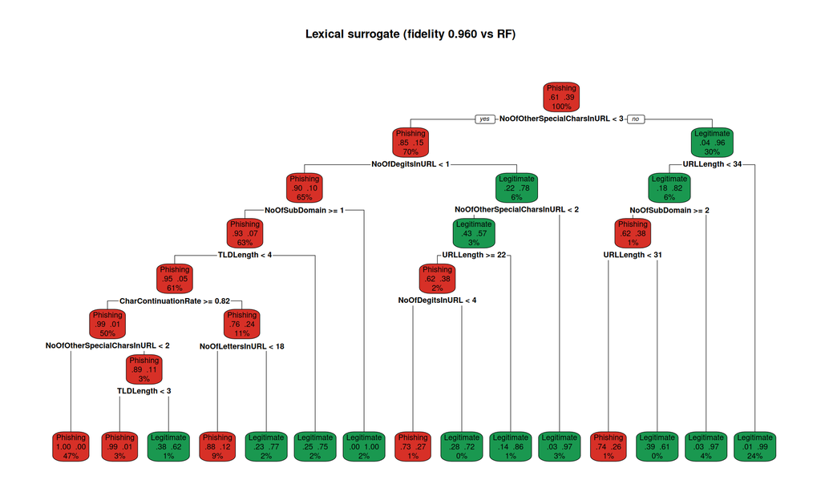

```r
key_lex <- winners %>% filter(tier == "Lexical") %>%
  transmute(key = sprintf("md=%d_cp=%.0e_mb=%d", maxdepth, cp, minbucket)) %>%
  pull(key)
tree_lex <- surr_lex$trees[[key_lex]]

if (has_rpart_plot) {
  rpart.plot::rpart.plot(
    tree_lex, type = 2, extra = 104, fallen.leaves = TRUE,
    box.palette = c("#D73027", "#1A9850"),
    main = sprintf("Lexical surrogate (fidelity %.3f vs RF)",
                   winners$fidelity[winners$tier == "Lexical"])
  )
} else {
  plot(tree_lex, uniform = TRUE, margin = 0.12,
       main = "Lexical surrogate tree")
  text(tree_lex, use.n = TRUE, cex = 0.65)
}
```

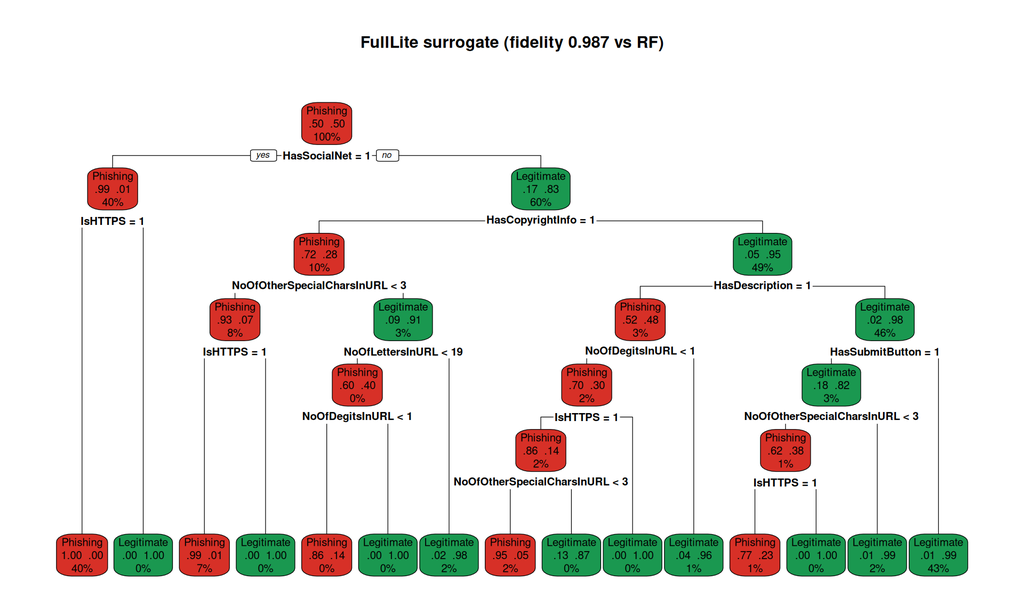

```r
key_full <- winners %>% filter(tier == "FullLite") %>%
  transmute(key = sprintf("md=%d_cp=%.0e_mb=%d", maxdepth, cp, minbucket)) %>%
  pull(key)
tree_full <- surr_full$trees[[key_full]]

if (has_rpart_plot) {
  rpart.plot::rpart.plot(
    tree_full, type = 2, extra = 104, fallen.leaves = TRUE,
    box.palette = c("#D73027", "#1A9850"),
    main = sprintf("FullLite surrogate (fidelity %.3f vs RF)",
                   winners$fidelity[winners$tier == "FullLite"])
  )
} else {
  plot(tree_full, uniform = TRUE, margin = 0.12,
       main = "FullLite surrogate tree")
  text(tree_full, use.n = TRUE, cex = 0.65)
}
```

### RF variable importance cross-check

The surrogate’s root split is a claim about what the RF thinks is the most discriminative single feature. To see whether that claim is faithful to the teacher - rather than an artefact of the one tree we plotted - we read the RF’s own variable importance for the same teacher and compare the ordering against the tree’s top few splits.

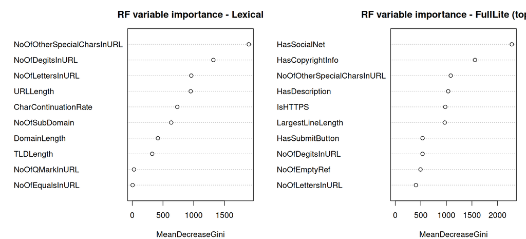

```r
# base-R title() goes through utf8towcs() which chokes on em-dashes
# in non-UTF-8 Windows locales - we keep the surrounding prose
# em-dashes intact but use a plain hyphen in the plot titles here.
op <- par(mfrow = c(1, 2), mar = c(4, 7, 3, 1))
randomForest::varImpPlot(
  rf_teachers[["Lexical"]],
  n.var = min(10, length(tiers[["Lexical"]])),
  main  = "RF variable importance - Lexical"
)
randomForest::varImpPlot(
  rf_teachers[["FullLite"]],
  n.var = 10,
  main  = "RF variable importance - FullLite (top 10)"
)
```

```r
par(op)
```

If the feature at the tree’s root is also in the top few rows of the RF importance plot for the same tier, the surrogate isn’t improvising - it’s picking up the same signal ranking the RF itself assigns. That is the evidence that lets us read the tree diagram as a visualisation of RF behaviour rather than a parallel classifier that happens to agree on the test set.

## 8.5 What the surrogate does and doesn’t capture

**What the surrogate visualises.** RF and the tree both work by axis-aligned splits, and on each tier the surrogate’s root variable is also `varImpPlot`’s top-ranked one.

So the diagram does reflect what RF actually keys on, not just a second classifier that happens to agree on the test set.